# visiumSpatialSolutions: Spatial Resolution

# Prerequisites

- Package Installation
- Data Availability
- Correct Fiducial Alignment
- Aligned Tissue positions (`rds` or `csv` file, or `data.frame` object, incl. information regarding orientation adjustments)

For ensuring the prerequisites are met, we recommend, checking out the Fiducial Detection vignette, first.

## Vignette Datasets

- [Visium_FFPE_Human_Ovarian_Cancer](https://www.10xgenomics.com/datasets/human-ovarian-cancer-1-standard)
- [CytAssist_11mm_FFPE_Human_Ovarian_Carcinoma](https://www.10xgenomics.com/datasets/human-ovarian-cancer-11-mm-capture-area-ffpe-2-standard)

The required files can be downloaded and extracted using the function `download_vignette_files()` as demonstrated in the Fiducial Detection vignette.

Alternatively, you can use your own data.

## Settings

```r
# load packages
library(dplyr)
library(visiumSpatialSolutions)

# define directories
output_dir <- file.path(getwd(), "data")
figures_dir <- file.path(getwd(), "figures")
```

# Visium spatial-array geometry

The derivation and visualization of candidate physical coordinate reconstructions for 6.5 mm and 11 mm Visium array are available in the [Reconstruction_Models](https://Zockimonster.github.io/visiumSpatialSolutions/).

The JSON-assisted coordinate dimensions are derived in [Spatial_Alignment](https://Zockimonster.github.io/visiumSpatialSolutions/).

## Define Array-specific settings

**Small array**

```r
L <- 6500
visium_sample <- "Visium_FFPE_Human_Ovarian_Cancer"
figures_sample <- file.path(figures_dir, visium_sample)
mtx_type <- "h5"
mtx_name <- "filtered"
img_res <- "hires"
```

**Large array**

```r
L <- 11000
visium_sample <- "CytAssist_11mm_FFPE_Human_Ovarian_Carcinoma"
figures_sample <- file.path(figures_dir, visium_sample)
mtx_type <- "h5"
mtx_name <- "filtered"
img_res <- "hires"
```

## Load input data

```r
spex <- load_spex(visium_dir=output_dir, visium_sample=visium_sample, matrix_name=mtx_name, matrix_file_format=mtx_type, image_resolution=img_res)
tp_aligned <- load_aligned_tp(file_dir=output_dir, visium_sample=visium_sample)
```

### Spatial Conversion

To align the spot positions with the spatially resolved image, we define the settings & use the function `spatial_conversion`:

```r
sfe <- spatial_conversion(aligned_tp=tp_aligned, spex=spex, L_capture_area=L, image_resolution =img_res)
```

**Spatial containment: The issue regarding the spots not being fully contained by the capture area using the default `spatial_geometry` with `hex100` is expected, so far.**

To create the spatially resolved plot using the colGeometry for `spatial_pixels`, we can use the function `create_sfe_plot`:

```r
sfe_plot <- create_sfe_plot(sfe=sfe, image_resolution= img_res)
```

Optionally, the spatially resolved plot can be saved to the `figures_sample` directory, using:

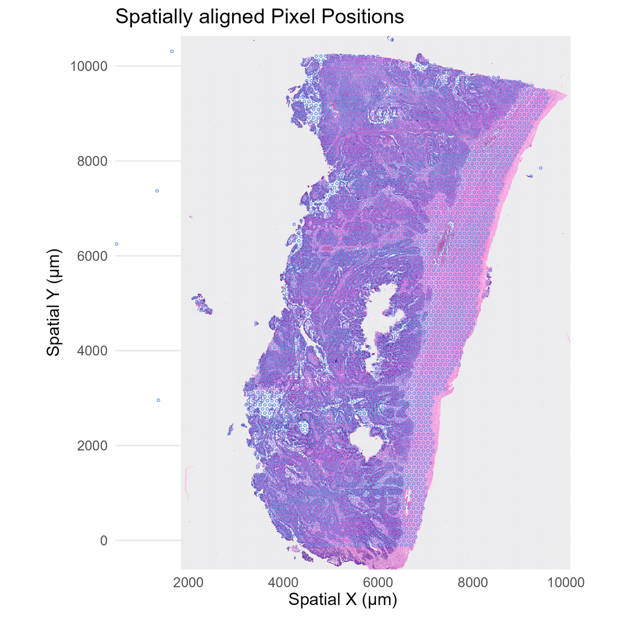

**Spatially resolved Image with aligned Spot Positions.**

```r
ggplot2::ggsave(filename = file.path(figures_sample, "spatially_resolved_plot.png"),
                plot= sfe_plot, width = 6, height = 6, units = "in")
```

### Interactive Spot Selection

The `SpatialFeatureExperiment` object with the spatially aligned array and pixel positions can further be used for interactive spot selection, with the tissue image overlaid by the spatially aligned `colGeometry` as specified in the argument `geom_id`. The selected barcodes can easily be downloaded as `csv` file using the `Download selected spots` button within the application. The `download_filename` can be adjusted in the function call, but also it can be changed when the download option is chosen.

```r
p_ia <- prepare_interactive_spot_selection(sfe, image_resolution =img_res, download_filename = "selected_A.csv")
shiny::shinyApp(p_ia$user_interface, p_ia$server_settings)
```

To reload selected barcodes and

- add this information to the spatially aligned tissue positions, we can use:

```r
# out_dir equals the directory, you selected for downloading the selected tissue positions
# since we selected the output_dir, we use
out_dir <- output_dir
selected_A <- read.csv(file.path(out_dir, "selected_A.csv"))
tp_aligned$selected_A <- ifelse(tp_aligned$barcode %in% selected_A$barcode, 1, 0)
table(tp_aligned$selected_A, useNA="ifany")
```

- add these to the `SpatialFeatureExperiment` object, we can use:

```r
SpatialFeatureExperiment::colGeometry(sfe, "spatial_pixels")$selected_A <- tp_aligned$selected_A[match(colnames(sfe, "spatial_pixels"), tp_aligned$barcode)]
```

### Multiple Sets of selected Spots

This application can easily be used for selecting distinct sets of spots, download the barcodes for each selection, and combine this information, afterwards:

Selection of B spots:

```r
p_ia <- prepare_interactive_spot_selection(sfe, image_resolution = img_res, download_filename="selected_B.csv")
shiny::shinyApp(p_ia$user_interface, p_ia$server_settings)
```

Afterwards, we can add and combine this information in the aligned tissue position data, using:

```r
selected_B <- read.csv(file.path(out_dir, "selected_B.csv"))
tp_aligned$selected_B <- ifelse(tp_aligned$barcode %in% selected_B$barcode, 1, 0)
SpatialFeatureExperiment::colGeometry(sfe, "spatial_pixels")$selected_B <- tp_aligned$selected_B[match(colnames(sfe, "spatial_pixels"), tp_aligned$barcode)]
table(tp_aligned$selected_A, tp_aligned$selected_B, useNA="ifany")
```

Which can be further combined into one column, using

```r
tp_aligned$selected_AB <- rep(NA_character_, nrow(tp_aligned))
tp_aligned$selected_AB[tp_aligned$selected_A == 0 & tp_aligned$selected_B== 0] <- "none"
tp_aligned$selected_AB[tp_aligned$selected_A == 1 & tp_aligned$selected_B== 0] <- "A"
tp_aligned$selected_AB[tp_aligned$selected_A == 0 & tp_aligned$selected_B== 1] <- "B"
tp_aligned$selected_AB[tp_aligned$selected_A == 1 & tp_aligned$selected_B== 1] <- "both"
table(tp_aligned$selected_AB, useNA="ifany")
```

To create a spatially resolved plot for the combined spot selection, we can add this information to the `colGeometry` of the sfe object, and use:

```r
SpatialFeatureExperiment::colGeometry(sfe, "spatial_pixels")$selected_AB <- tp_aligned$selected_AB[match(colnames(sfe, "spatial_pixels"), tp_aligned$barcode)]
AB_plot <- create_sfe_plot(sfe, image_resolution =img_res, color_by="selected_AB", plot_title="AB Spot Selection", color_source = "geometry")
```

Optionally, the plot with the spatially resolved spot selection can be saved to the `figures_sample` directory, using:

```r
ggplot2::ggsave(filename = file.path(figures_sample, "spatially_resolved_spot_selection.png"),
                plot= AB_plot, width = 6, height = 6, units = "in")
```

Exemplary, we created one plot for 2 spot selections for the small sample:

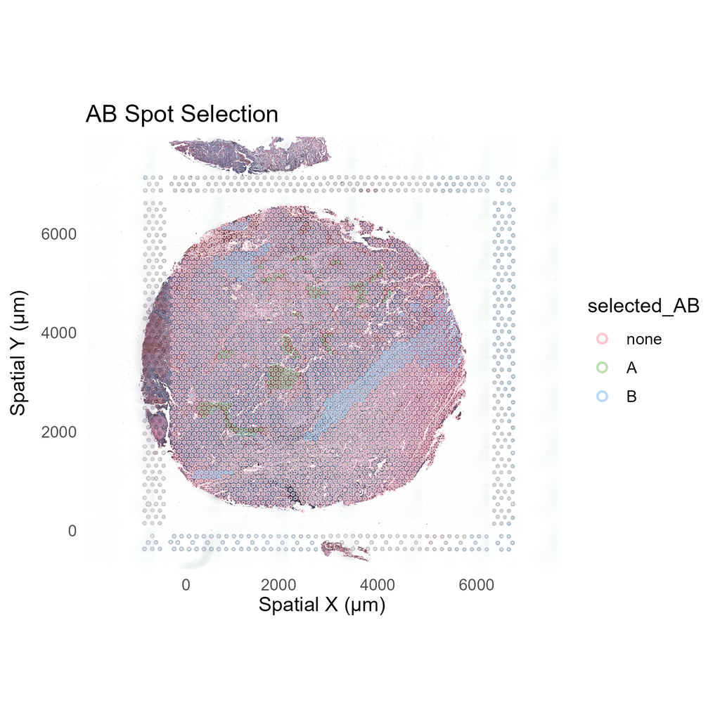

**Spatially resolved Image with aligned Spot Selection.**